# Week 5, Lecture 10 Advanced statistical methods, part I: Ecological analyses, ordinal data, and dimensionality reduction

Richard E.W. Berl

Spring 2019

## Dimensionality reduction

Dimensionality reduction, like its name suggests, is used to reduce the number of dimensions in our data set. In other words, we want to reduce the number of variables to be used to model the data without losing too much of the variance those variables explain.

This is a common problem. It’s difficult to imagine points laid out in 12-dimensional space. It’s easier to see points in a 2-dimensional (X x Y) or 3-dimensional (X x Y x Z) space. It’s also useful to see how our data can be simplified and clustered.

Let’s load our Bob Marshall onsite survey data back in:

```r
bm = read.csv("./data/BMWC2004_onsitedata.csv", header=T, na.strings="88",
              stringsAsFactors=F)
bm$recent_f[bm$recent_f == 0] = NA

bmLik = bm
bmLik[,36:45] = lapply(bmLik[,36:45], function(x) ordered(x))
```

And recreate our correlation matrix:

```r
library(lavaan)
bmLikCor = lavCor(bmLik[,36:45])
```

Let’s also load our previously saved “best” Christmas Bird Count data:

```r
best = read.csv("./data/fcbirdbest.csv", header=T, row.names=1)
```

And finally, we’ll also bring back our old Indo-European folktale data from Lecture 03:

```r
library(readxl)
```

```r
folktales = as.data.frame(read_xlsx(path="./data/rsos150645supp1.xlsx",
                                    sheet=1, range="A2:JP52"))
colnames(folktales)[1] = "society"
```

### Multidimensional scaling

In my experience, primarily used as a way to visualize a distance matrix. However, there are other applications in ecology.

We’ll use our Bob Marshall Wilderness survey data, but right now we have a correlation matrix. We need to convert this from a measure of similarity or association (correlation) to a measure of dissimilarity (distance).

We could do it manually, but luckily there’s a function in the `psych` package, which we were planning on loading later anyway, to do it for us.

```r
install.packages("psych")
```

```r
library(psych)
?cor2dist
```

```r
bmLikDist = as.dist(cor2dist(bmLikCor))
bmLikDist
```

```
##            natural  remotnes  scenic_b   hunting   fishing  recent_f
## remotnes 0.5704977
## scenic_b 1.0515567 0.9863890
## hunting  1.4615125 1.4393572 1.5125929
## fishing  1.3603630 1.3329079 1.4377701 0.8566035
## recent_f 1.3198146 1.3881493 1.1623764 1.2596373 1.4117703
## test_ski 1.2981759 1.4014717 1.2798294 1.2405682 1.4147664 1.1854113
## familiar 1.3609819 1.3644849 1.2606143 1.2996073 1.3103081 1.2660455
## variety  1.3184390 1.2984087 1.2842120 1.4259006 1.4726524 1.4263578
## friend_s 1.3824247 1.3641166 1.2151582 1.4267610 1.4266808 1.3921892
##           test_ski  familiar   variety
## remotnes
## scenic_b
## hunting
## fishing
## recent_f
## test_ski
## familiar 1.2210226
## variety  1.2355076 1.5686837
## friend_s 1.3660988 1.5218809 1.1418339
```

#### **Classical**

Represents the distance between points on a two-dimensional plane.

```r
?cmdscale
```

```r
bmCMD = cmdscale(bmLikDist)
bmCMD
```

```
##                [,1]        [,2]
## natural  -0.5152544 -0.41355292
## remotnes -0.5360831 -0.41294618
## scenic_b -0.4665433 -0.14344422
## hunting   0.7581483  0.04870982
## fishing   0.5974677 -0.13641546
## recent_f  0.1613884 -0.04454814
## test_ski  0.1734981  0.19224084
## familiar  0.3327288 -0.43118845
## variety  -0.2869680  0.67972386
## friend_s -0.2183826  0.66142085
```

We can use these coordinates to plot the points, and add text labels.

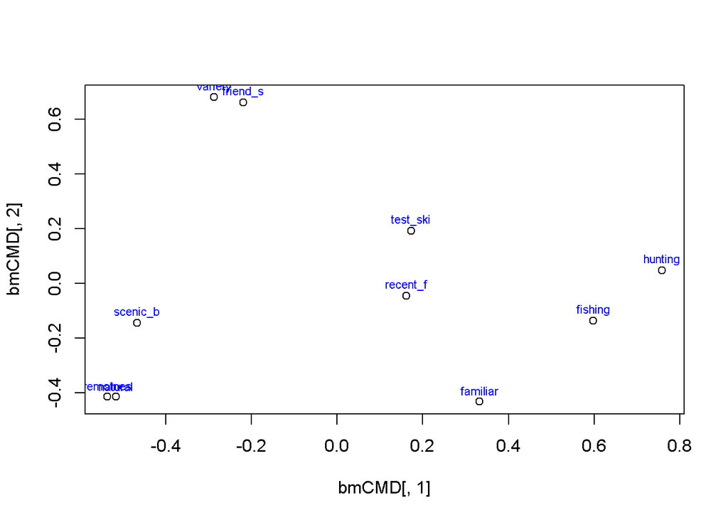

```r
plot(bmCMD[,1], bmCMD[,2])
text(bmCMD[,1], bmCMD[,2] + 0.04,
     labels=rownames(bmCMD), col="blue", cex=0.7)
```

#### **Nonmetric**

Tries to reproduce ranks of distances (furthest, second furthest, etc.) rather than the distance values themselves.

```r
library(MASS)
```

```r
?isoMDS
```

```r
bmNMD = isoMDS(bmLikDist)
bmNMD
```

```
## $points
##                [,1]        [,2]
## natural  -0.2914076 -0.22953015
## remotnes -0.2963235 -0.23046987
## scenic_b -0.3703879 -0.23513955
## hunting   0.6799271  0.14245565
## fishing   0.5972598  0.01257943
## recent_f  0.1750672 -0.08985301
## test_ski  0.1160045  0.27390459
## familiar  0.3008428 -0.52798807
## variety  -0.4908231  0.46848012
## friend_s -0.4201593  0.41556086
##
## $stress
## [1] 13.7677
```

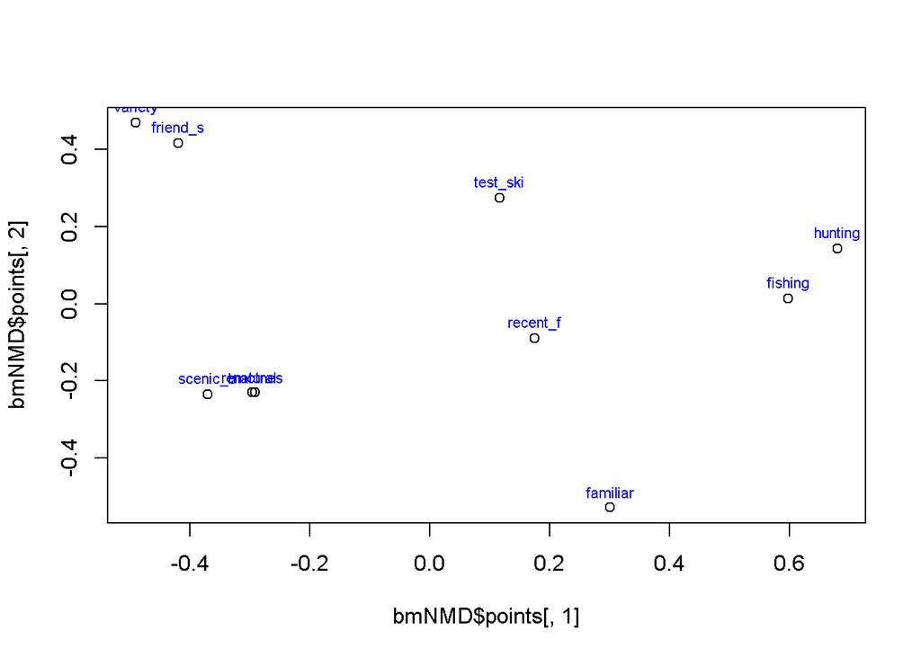

```r
plot(bmNMD$points[,1], bmNMD$points[,2])
text(bmNMD$points[,1], bmNMD$points[,2] + 0.04,
     labels=rownames(bmNMD$points), col="blue", cex=0.7)
```

A more thorough version is available in the `vegan` package, `metaMDS()`, which has some additional features and compares the results of a bunch of attempts.

```r
library(vegan)
?metaMDS
```

```r
head(best)
```

```
##      American.Crow American.Dipper American.Goldfinch American.Kestrel
## 1952           353              12                 16                2
## 1956             5               2                 36                2
## 1957             3               3                  7                3
## 1958           168               8                  3                7
## 1960             2               5                  3                6
## 1962           590              20                  6                2
```

```r
bestNMD = metaMDS(best)
```

```
## Square root transformation
## Wisconsin double standardization
## *** Solution reached
```

```r
bestNMD
```

```
##
## Call:
## metaMDS(comm = best)
##
## global Multidimensional Scaling using monoMDS
##
## Data:     wisconsin(sqrt(best))
## Distance: bray
##
## Dimensions: 2
## Stress:     0.08928881
## Stress type 1, weak ties
## Two convergent solutions found after 20 tries
## Scaling: centring, PC rotation, halfchange scaling
## Species: expanded scores based on 'wisconsin(sqrt(best))'
```

Here we can plot the sites and the species on the same axes.

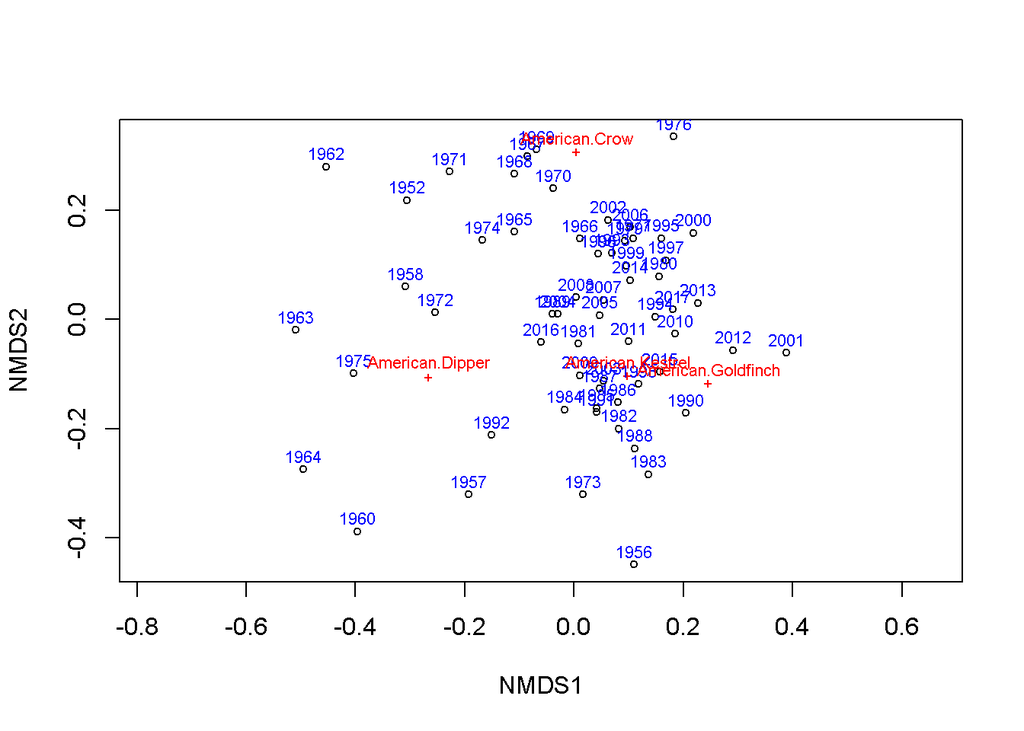

```r
plot(bestNMD)
text(bestNMD$points[,1], bestNMD$points[,2] + 0.025,
     labels=rownames(bestNMD$points), col="blue", cex=0.7)
text(bestNMD$species[,1], bestNMD$species[,2] + 0.025,
     labels=rownames(bestNMD$species), col="red", cex=0.7)
```

### Principal components analysis

Principal components analysis (PCA) is very commonly used in the literature, and breaks the data down into a number of components that explain the most variance (in the first component) to the least variance (in the last component).

One of the main challenges in dimensionality reduction is determining the number of components or factors that is most appropriate for the data. Here we’re going to assume we only want two components, but in the following sections we’ll go over some methods that also apply to PCA.

There are a number of functions in different packages that can perform PCA. One is in `base` R.

```r
?princomp
```

The one we’ll use here is `principal()`, from the `psych` package, mainly because it allows us to input our own correlation matrix instead of calculating correlations itself from raw data (like `princomp()`). We definitely wouldn’t want to do that with the data we intend to use here, which are the dichotomous presence/absence folktale data.

```r
?psych::principal
```

```r
folk = as.data.frame(t(folktales[,-1]))
colnames(folk) = folktales$society
folk[1:5,1:10]
```

```
##      Italian Ladin Sardinian Walloon French Spanish Portuguese Catalan
## 300        1     1         1       1      1       1          1       1
## 300A       0     0         0       0      0       0          0       0
## 301        1     1         1       1      1       1          1       1
## 301D       0     0         0       0      0       0          0       0
## 302        1     1         1       0      1       1          1       1
##      Romanian Welsh
## 300         1     0
## 300A        1     0
## 301         1     0
## 301D        0     0
## 302         1     0
```

```r
str(folk)
```

```
## 'data.frame':    275 obs. of  50 variables:
##  $ Italian      : num  1 0 1 0 1 0 0 1 0 0 ...
##  $ Ladin        : num  1 0 1 0 1 0 0 1 0 1 ...
##  $ Sardinian    : num  1 0 1 0 1 0 0 1 0 0 ...
##  $ Walloon      : num  1 0 1 0 0 0 0 1 0 0 ...
##  $ French       : num  1 0 1 0 1 0 0 1 1 1 ...
##  $ Spanish      : num  1 0 1 0 1 0 0 1 0 1 ...
##  $ Portuguese   : num  1 0 1 0 1 0 0 1 0 1 ...
##  $ Catalan      : num  1 0 1 0 1 0 0 1 0 0 ...
##  $ Romanian     : num  1 1 1 0 1 0 1 1 1 1 ...
##  $ Welsh        : num  0 0 0 0 0 0 0 0 0 0 ...
##  $ Irish        : num  1 0 1 0 1 0 0 1 0 1 ...
##  $ Scottish     : num  1 0 1 0 1 0 0 1 0 0 ...
##  $ Luxembourgish: num  0 0 0 0 0 0 0 0 0 0 ...
##  $ German       : num  1 1 1 0 1 0 1 1 1 1 ...
```

[output cut: 36 more lines]

**Tetrachoric correlation**

Just as we used polychoric correlations for ordinal data, we need to use a specialized method for dichotomous (binary) data. This is the tetrachoric correlation, a specific case of the polychoric correlation. The `psych` package has a function to handle this:

```r
?psych::tetrachoric
```

```r
folkCor = tetrachoric(folk)$rho
```

[output not shown]

[output not shown]

[output not shown]

[output not shown]

[output not shown]

[output not shown]

[output not shown]

[output not shown]

[output not shown]

[output not shown]

[output not shown]

[output not shown]

[output not shown]

[output not shown]

[output not shown]

[output not shown]

[output not shown]

[output not shown]

[output not shown]

[output not shown]

[output not shown]

[output not shown]

[output not shown]

[output not shown]

[output not shown]

[output not shown]

[output not shown]

[output not shown]

[output not shown]

[output not shown]

[output not shown]

[output not shown]

[output not shown]

[output not shown]

[output not shown]

[output not shown]

```
## Warning in cor.smooth(mat): Matrix was not positive definite, smoothing was
## done
```

```r
folkCor[1:10,1:10]
```

```
##              Italian     Ladin Sardinian   Walloon    French   Spanish
## Italian    1.0000000 0.6143107 0.7672081 0.5822875 0.7623941 0.7019760
## Ladin      0.6143107 1.0000000 0.5082589 0.4529498 0.6912242 0.5869226
## Sardinian  0.7672081 0.5082589 1.0000000 0.4697491 0.6411595 0.5570139
## Walloon    0.5822875 0.4529498 0.4697491 1.0000000 0.5475553 0.3977685
## French     0.7623941 0.6912242 0.6411595 0.5475553 1.0000000 0.7574446
## Spanish    0.7019760 0.5869226 0.5570139 0.3977685 0.7574446 1.0000000
## Portuguese 0.6514227 0.4780249 0.5945318 0.3558462 0.6855161 0.7875559
## Catalan    0.7661892 0.5715129 0.5199610 0.5004013 0.7938338 0.8457141
## Romanian   0.4675313 0.5093527 0.5261116 0.3636709 0.5062839 0.4811890
## Welsh      0.3112035 0.3171770 0.1855564 0.2100189 0.4494361 0.4542234
##            Portuguese   Catalan  Romanian     Welsh
## Italian     0.6514227 0.7661892 0.4675313 0.3112035
## Ladin       0.4780249 0.5715129 0.5093527 0.3171770
## Sardinian   0.5945318 0.5199610 0.5261116 0.1855564
## Walloon     0.3558462 0.5004013 0.3636709 0.2100189
## French      0.6855161 0.7938338 0.5062839 0.4494361
## Spanish     0.7875559 0.8457141 0.4811890 0.4542234
## Portuguese  1.0000000 0.6911430 0.4440923 0.4418054
## Catalan     0.6911430 1.0000000 0.4819166 0.4794101
## Romanian    0.4440923 0.4819166 1.0000000 0.3790717
## Welsh       0.4418054 0.4794101 0.3790717 1.0000000
```

Note the warnings about bivariate cell corrections, but it should be okay to leave it at the default correction of 0.5.

For more information, see:

Savalei, V. (2011). What to do about zero frequency cells when estimating polychoric correlations. Structural Equation Modeling, 18(2), 253-273. doi: 10.1080/10705511.2011.557339

Smoothing ensures the matrix isn’t singular and is usually also okay, but be cautious. A singular matrix could be a sign of multicollinearity in your data.

Now we can go ahead with the PCA:

```r
folkPCA = principal(folkCor, 2, rotate="none")
folkPCA
```

```
## Principal Components Analysis
## Call: principal(r = folkCor, nfactors = 2, rotate = "none")
## Standardized loadings (pattern matrix) based upon correlation matrix
##                PC1   PC2   h2   u2 com
## Italian       0.80 -0.07 0.65 0.35 1.0
## Ladin         0.77 -0.15 0.62 0.38 1.1
## Sardinian     0.69  0.05 0.48 0.52 1.0
## Walloon       0.61 -0.09 0.38 0.62 1.0
## French        0.87 -0.16 0.79 0.21 1.1
## Spanish       0.76 -0.13 0.59 0.41 1.1
## Portuguese    0.67  0.08 0.45 0.55 1.0
## Catalan       0.79 -0.05 0.63 0.37 1.0
## Romanian      0.69  0.23 0.54 0.46 1.2
## Welsh         0.48 -0.38 0.37 0.63 1.9
## Irish         0.85 -0.13 0.74 0.26 1.0
## Scottish      0.50 -0.37 0.39 0.61 1.9
## Luxembourgish 0.38 -0.42 0.32 0.68 2.0
## German        0.77 -0.28 0.66 0.34 1.3
## Austrian      0.77 -0.13 0.61 0.39 1.1
## Flemish       0.76 -0.11 0.58 0.42 1.0
## Dutch         0.59 -0.41 0.52 0.48 1.8
## Frisian       0.71 -0.31 0.60 0.40 1.4
## English       0.52 -0.39 0.42 0.58 1.9
## Swedish       0.82 -0.19 0.71 0.29 1.1
## Norwegian     0.74 -0.20 0.58 0.42 1.2
## Danish        0.75 -0.23 0.62 0.38 1.2
## Faroese       0.71 -0.01 0.50 0.50 1.0
## Icelandic     0.69 -0.13 0.50 0.50 1.1
## Czech         0.82 -0.16 0.69 0.31 1.1
## Slovak        0.83 -0.03 0.69 0.31 1.0
## Lusatian      0.75 -0.20 0.60 0.40 1.1
## Polish        0.74 -0.08 0.56 0.44 1.0
## Byelorussian  0.70  0.07 0.49 0.51 1.0
## Ukrainian     0.74  0.04 0.56 0.44 1.0
## Russian       0.69 -0.02 0.48 0.52 1.0
## Bulgarian     0.71  0.36 0.63 0.37 1.5
## Macedonian    0.41  0.58 0.51 0.49 1.8
## Serbian       0.59  0.17 0.38 0.62 1.2
## Croation      0.56  0.16 0.34 0.66 1.2
## Slovenenian   0.81 -0.15 0.69 0.31 1.1
```

[output cut: 13 more lines]

```
## Armenian      0.60  0.52 0.63 0.37 2.0
##
##                         PC1  PC2
## SS loadings           22.13 4.55
## Proportion Var         0.44 0.09
## Cumulative Var         0.44 0.53
## Proportion Explained   0.83 0.17
## Cumulative Proportion  0.83 1.00
##
## Mean item complexity =  1.3
## Test of the hypothesis that 2 components are sufficient.
##
## The root mean square of the residuals (RMSR) is  0.08
##
## Fit based upon off diagonal values = 0.97
```

And plot it:

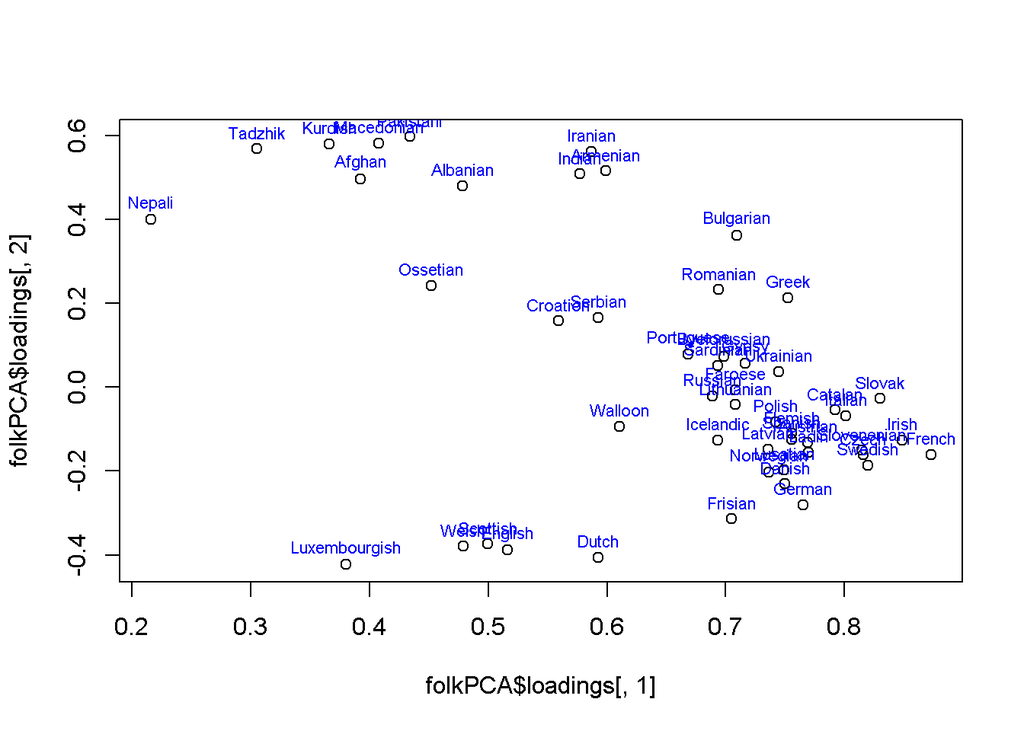

```r
plot(folkPCA$loadings[,1], folkPCA$loadings[,2])
text(folkPCA$loadings[,1], folkPCA$loadings[,2] + 0.04,
     labels=rownames(folkPCA$loadings), col="blue", cex=0.7)
```

### Cluster analysis

We often want to know what groups exist in our data, either to get a better sense of what our data looks like, how it represents groups that we know exist in the data, or for classification if we want to predict which group an observation would fall in given a set of values. For all this, there’s cluster analysis.

#### **Hierarchical clustering**

Hierarchical clustering builds a tree (or “dendrogram”) out of our data, successively linking the most closely associated observations or variables. It’s one of the simplest and most widely used methods, and is a good EDA method.

There are a variety of clustering methods within hierarchical clustering. Ward’s method usually gives good results, but check others to see what’s most appropriate for your data.

```r
?hclust
```

```r
bmHC = hclust(bmLikDist, method="ward.D2")
```

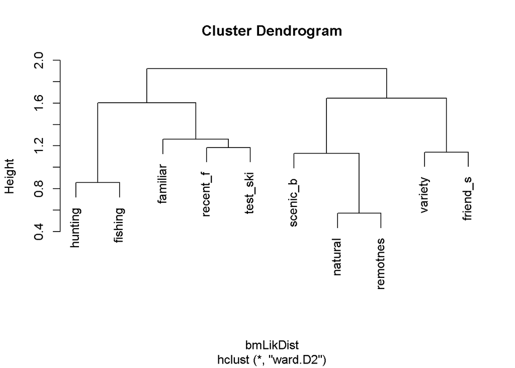

```r
plot(bmHC)
```

We’ve seen hierarchical clustering before, in the trees shown alongside the output of the `heatmap()` function:

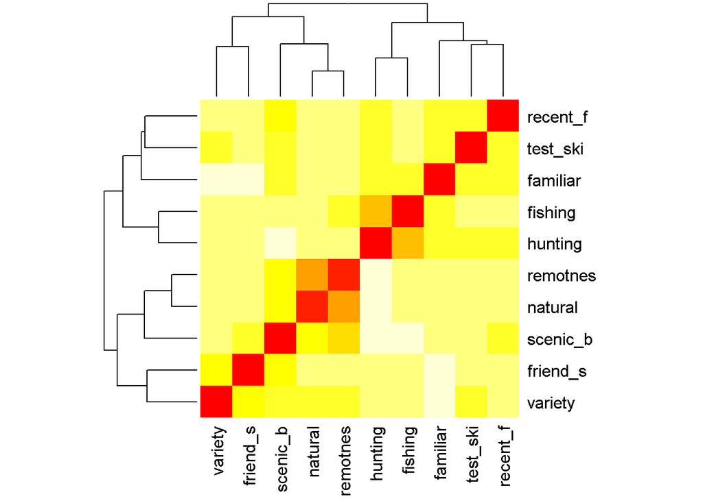

```r
heatmap(as.matrix(bmLikDist),
        hclustfun=function(x) hclust(x, method="ward.D2"))
```

Another implementation is available in the `pvclust` package, which is handy because it gives us some estimates of our confidence in the different clusters. The bad news is that it only takes raw numeric data and does not allow a distance matrix as input. Therefore, our conclusions about this with ordinal data will not be great, but we can do it anyway to demonstrate.

```r
install.packages("pvclust")
```

```r
library(pvclust)
```

```r
?pvclust
```

```r
# Note: Takes some time to run
bmPVHC = pvclust(bm[,36:45], method.hclust="ward.D2")
```

```
## Bootstrap (r = 0.5)... Done.
## Bootstrap (r = 0.6)... Done.
## Bootstrap (r = 0.7)... Done.
## Bootstrap (r = 0.8)... Done.
## Bootstrap (r = 0.9)... Done.
## Bootstrap (r = 1.0)... Done.
## Bootstrap (r = 1.1)... Done.
## Bootstrap (r = 1.2)... Done.
## Bootstrap (r = 1.3)... Done.
## Bootstrap (r = 1.4)... Done.
```

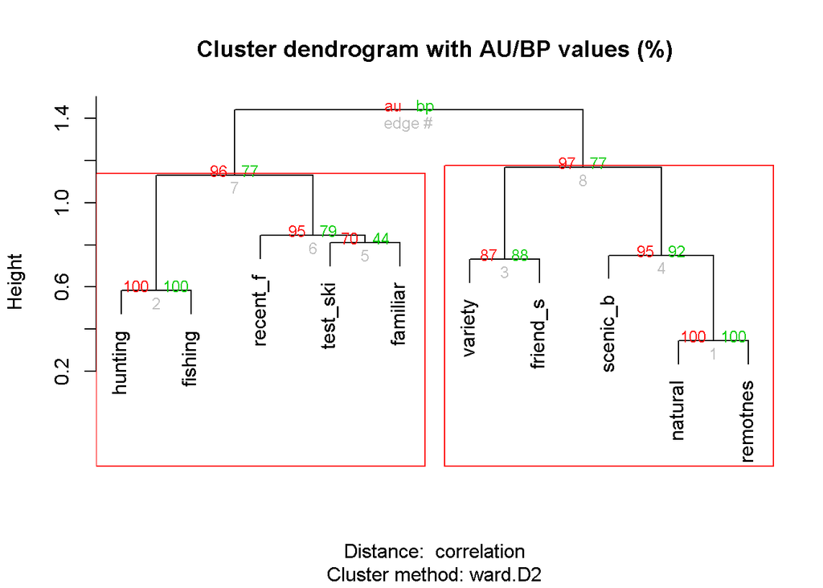

```r
plot(bmPVHC)
pvrect(bmPVHC)
```

Red = “AU” (Approximately Unbiased) _p_value: 1 - *p*-value (>95 is “significant”)

Green = “BP” (Bootstrap Probability): percent of times the tree-building algorithm produced that branch

#### **K-means clustering**

A very common and flexible method, especially in machine learning.

```r
?kmeans
```

It does not work with any missing values, so you have to remove or impute them beforehand. Since we’ve already done that for our bird count data set, let’s use it.

As mentioned before, we need some way to decide how many clusters to split the data into–these clustering methods don’t do it for us automatically. One way is the “elbow method,” in which we plot the total within sum of squares (how far our points are from the values predicted by a model) that result from using different numbers of clusters, and pick the lowest cluster number that shows a substantial drop in SS from the previous number. This forms an “elbow” or inflection point where the line changes direction.

A method for doing this (aside from doing it manually) is built into the `factoextra` package as `fviz_nbclust()`.

```r
install.packages("factoextra")
```

```r
library(factoextra)
```

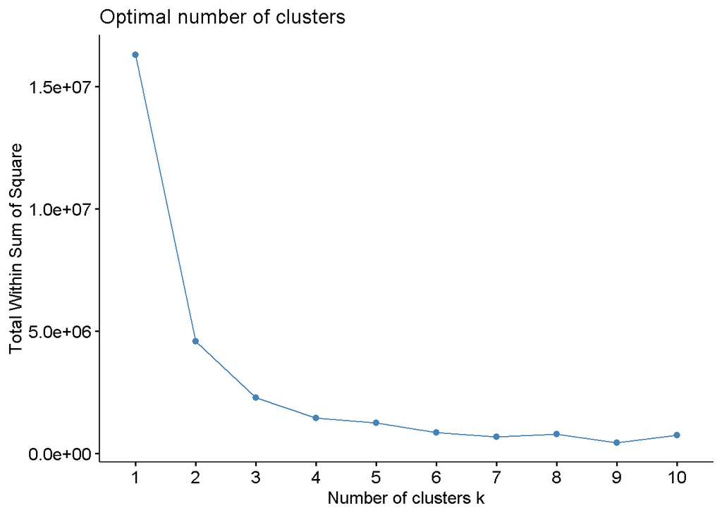

```r
fviz_nbclust(best, kmeans, "wss")
```

We can see big drops in SS from 1 to 2, 2 to 3, and 3 to 4 clusters, but from 4 to 5 it stays more or less the same, so we wouldn’t get much benefit from adding more clusters.

Another method for deciding the number of clusters is based on the average “silhouette width” value of each observation or variable, which is a measure of how well that item fits in its respective cluster. The solution with the highest average silhouette value across all items should logically be the one that fits all of them the best.

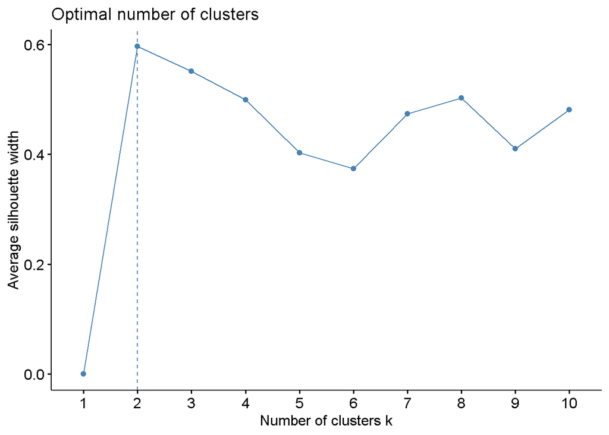

```r
fviz_nbclust(best, kmeans, "silhouette")
```

This one suggests 2 clusters. Since the two methods disagree, let’s try both and see which one looks like it makes the most sense.

```r
bestKM4 = kmeans(best, 4)
bestKM4
```

```
## K-means clustering with 4 clusters of sizes 10, 20, 15, 15
##
## Cluster means:
##   American.Crow American.Dipper American.Goldfinch American.Kestrel
## 1     1504.0000        17.80000           199.4000         67.80000
## 2      115.8500        11.50000            59.5500         21.45000
## 3      478.6667        13.46667            95.2000         30.66667
## 4      928.0000        18.26667           195.2667         63.53333
##
## Clustering vector:
## 1952 1956 1957 1958 1960 1962 1963 1964 1965 1966 1967 1968 1969 1970 1971
##    3    2    2    2    2    3    2    2    2    3    4    4    4    3    3
## 1972 1973 1974 1975 1976 1977 1979 1980 1981 1982 1983 1984 1985 1986 1987
##    2    2    3    2    1    3    3    4    3    2    2    2    2    2    2
## 1988 1989 1990 1991 1992 1993 1994 1995 1996 1997 1998 1999 2000 2001 2002
##    2    3    2    2    2    4    3    4    1    1    3    1    1    3    1
## 2003 2004 2005 2006 2007 2008 2009 2010 2011 2012 2013 2014 2015 2016 2017
##    3    4    1    1    1    4    3    4    4    4    4    1    4    4    4
##
## Within cluster sum of squares by cluster:
## [1] 412681.6 186471.5 359440.8 496603.6
##  (between_SS / total_SS =  91.1 %)
##
## Available components:
##
## [1] "cluster"      "centers"      "totss"        "withinss"
## [5] "tot.withinss" "betweenss"    "size"         "iter"
## [9] "ifault"
```

We see a breakdown of our results. First, we can see that it is clustering by “site” (year, in this case), so if that’s not what we want we’d have to transpose our data to have it cluster by species. It gives us information on the mean values of each species within each of the 4 clusters, and which cluster each year was assigned to.

Let’s visualize our clusters with `fviz_cluster()` from `factoextra`.

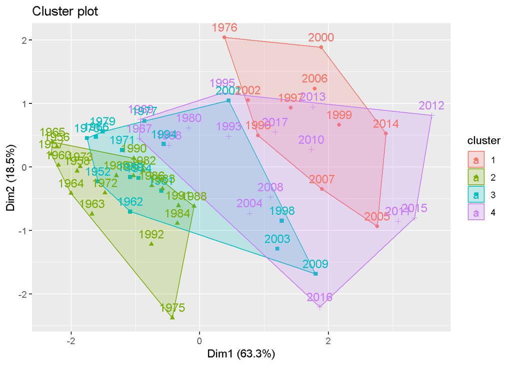

```r
fviz_cluster(bestKM4, data=best, show.clust.cent=F)
```

Doesn’t look like a great solution to me, personally. There’s a lot of overlap in our 4 clusters and it’s not immediately clear what could cause the separation.

Let’s take a look at a 2-cluster solution.

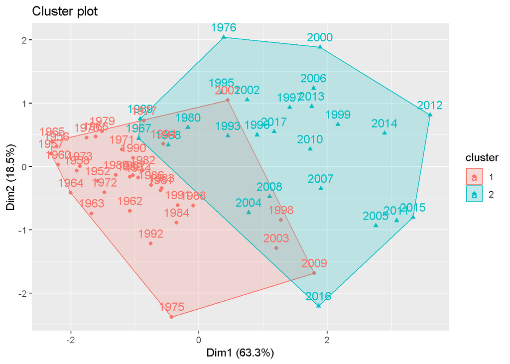

```r
bestKM2 = kmeans(best, 2)
fviz_cluster(bestKM2, data=best, show.clust.cent=F)
```

Looks much better to me, so I’d probably favor this solution. We can see (generally) earlier years in the cluster on the left, and later years (plus 1976, oddly) on the right.

As we observed, this clustered by row (year). What if we want to cluster by column (species) instead?

We need to check again for the appropriate number of clusters. This time, since we have so few variables, we’ll need to limit the maximum number of clusters to the number of observations minus one, which is the most possible without having each individual point as its own cluster.

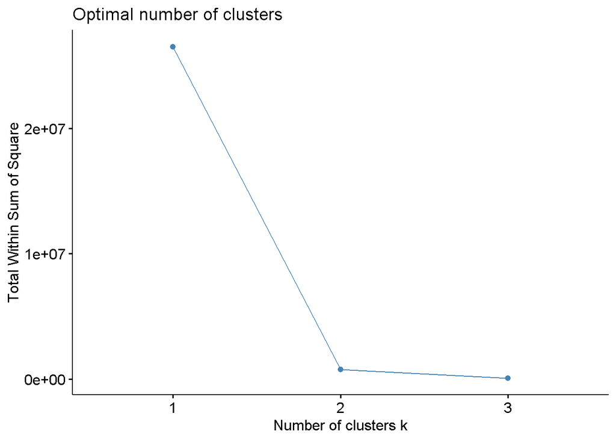

```r
fviz_nbclust(t(best), kmeans, "wss", k.max=nrow(t(best)) - 1)
```

Looks like 2.

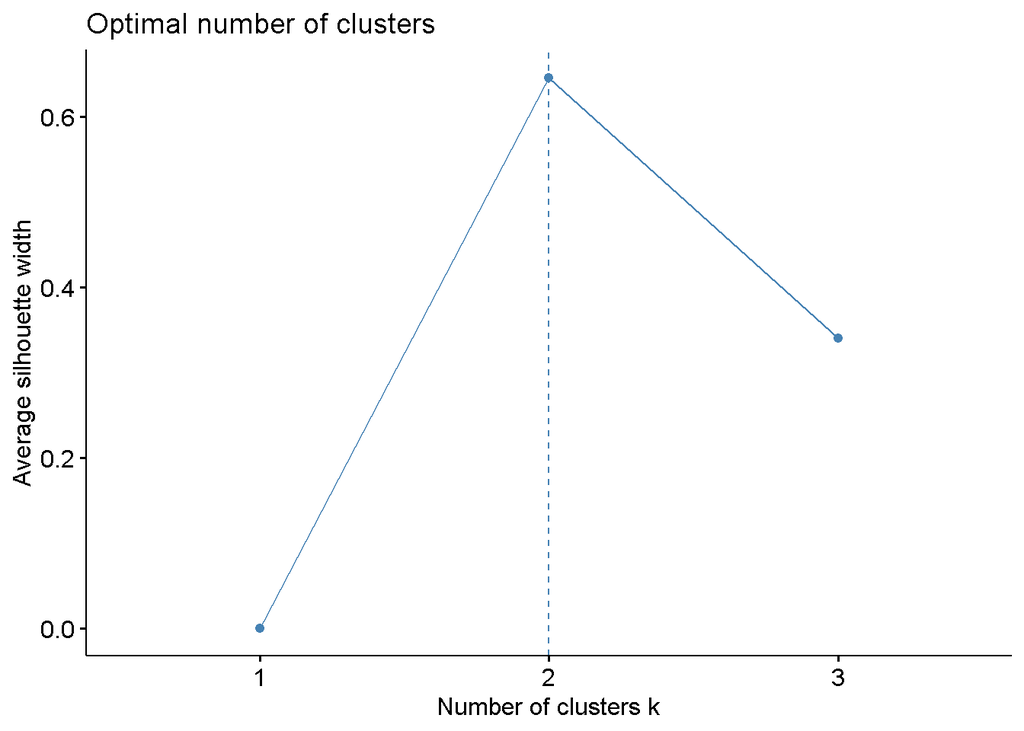

```r
fviz_nbclust(t(best), kmeans, "silhouette", k.max=nrow(t(best)) - 1)
```

Again, we get 2. It always helps us be more confident in the result when different methods agree.

```r
bestTKM2 = kmeans(t(best), 2)
bestTKM2
```

```
## K-means clustering with 2 clusters of sizes 3, 1
##
## Cluster means:
##   1952     1956     1957 1958     1960       1962 1963      1964
## 1   10 13.33333 4.333333    6 4.666667   9.333333    7  5.666667
## 2  353  5.00000 3.000000  168 2.000000 590.000000  130 13.000000
##         1965      1966      1967       1968      1969 1970 1971 1972
## 1   3.333333  16.33333  23.33333   26.66667  17.33333   13   10   12
## 2 100.000000 390.00000 870.00000 1100.00000 990.00000  390  720  248
##       1973      1974      1975       1976      1977      1979      1980
## 1 22.33333  18.33333  21.33333   60.33333  33.33333  19.33333  66.33333
## 2 29.00000 623.00000 250.00000 1756.00000 644.00000 362.00000 731.00000
##        1981 1982 1983      1984      1985 1986 1987 1988      1989
## 1  43.33333   41   74  51.33333  32.33333   50   37   82  27.66667
## 2 357.00000  125   85 184.00000 104.00000  159  166  127 352.00000
##        1990      1991     1992 1993      1994 1995       1996      1997
## 1  57.66667  57.66667 33.66667   71  50.33333   67   64.33333  109.6667
## 2 148.00000 173.00000 98.00000 1111 419.00000 1137 1266.00000 1346.0000
##       1998 1999      2000 2001       2002     2003 2004      2005
## 1 122.3333  109  106.3333  116   57.66667 104.3333   61  132.6667
## 2 495.0000 1663 1672.0000  486 1469.00000 448.0000  799 1304.0000
##         2006 2007       2008 2009     2010      2011     2012      2013
## 1   81.33333  110   73.66667  103 132.3333  157.3333 187.3333  120.3333
## 2 1713.00000 1239 1019.00000  551 805.0000 1037.0000 894.0000 1005.0000
##        2014 2015 2016     2017
## 1  118.6667  184   88 109.6667
## 2 1612.0000  748  803 871.0000
##
## Clustering vector:
##      American.Crow    American.Dipper American.Goldfinch
##                  2                  1                  1
##   American.Kestrel
##                  1
##
## Within cluster sum of squares by cluster:
## [1] 766650.7      0.0
##  (between_SS / total_SS =  97.1 %)
##
## Available components:
##
## [1] "cluster"      "centers"      "totss"        "withinss"
## [5] "tot.withinss" "betweenss"    "size"         "iter"
## [9] "ifault"
```

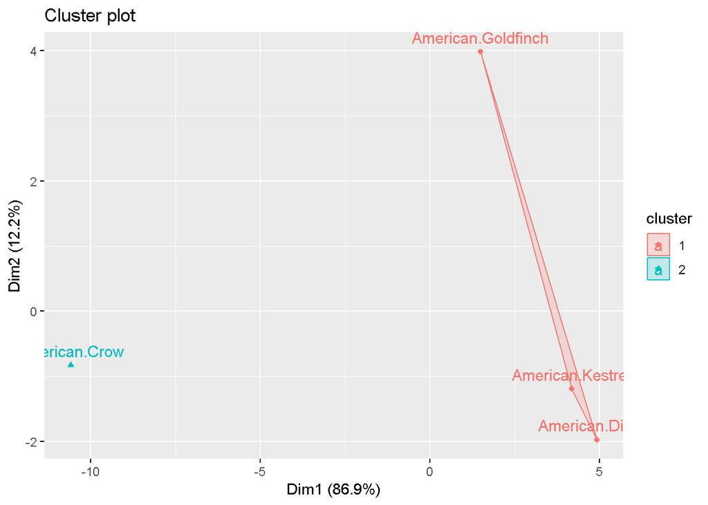

```r
fviz_cluster(bestTKM2, data=t(best), show.clust.cent=F)
```

Looks good overall, though we have so few variables to cluster that it doesn’t mean a whole lot. But we see American Crow on its own, and all the rest in a separate cluster. I could imagine American Goldfinch breaking off in a different cluster if we had more data.

#### **K-medoids clustering**

A type of clustering in the same family of methods as k-means, but using median values in each cluster instead of means. The algorithm we’ll use here is called Partitioning Around Medoids (or PAM) and is implemented as `pam()` in the `cluster` package.

FOr our purposes, PAM is most useful because of its ability to accept distance matrices (while `kmeans` only takes raw data), meaning we can conduct comparable clustering analyses on all kinds of different data as long as we can generate distance matrices from them. It also has a nice method (using the `pamk()` function in the `fpc` package) to calculate the appropriate number of clusters on its own, using average silhouette widths.

```r
install.packages("cluster")
```

```r
library(cluster)
```

```r
?pam
```

```r
install.packages("fpc")
```

```r
library(fpc)
```

```r
?pamk
```

We’ll use our folktale data again, and convert our correlation matrix to a distance matrix.

```r
folkDist = as.dist(cor2dist(folkCor))
as.matrix(folkDist)[1:10,1:10]
```

```
##              Italian     Ladin Sardinian   Walloon    French   Spanish
## Italian    0.0000000 0.8782816 0.6823370 0.9140159 0.6893560 0.7720415
## Ladin      0.8782816 0.0000000 0.9917067 1.0459926 0.7858445 0.9089306
## Sardinian  0.6823370 0.9917067 0.0000000 1.0298067 0.8471606 0.9412610
## Walloon    0.9140159 1.0459926 1.0298067 0.0000000 0.9512568 1.0974803
## French     0.6893560 0.7858445 0.8471606 0.9512568 0.0000000 0.6964989
## Spanish    0.7720415 0.9089306 0.9412610 1.0974803 0.6964989 0.0000000
## Portuguese 0.8349579 1.0217388 0.9005201 1.1350364 0.7930749 0.6518344
## Catalan    0.6838287 0.9257290 0.9798357 0.9995986 0.6421311 0.5554924
## Romanian   1.0319581 0.9906031 0.9735383 1.1281215 0.9936963 1.0186373
## Welsh      1.1737091 1.1686086 1.2762787 1.2569655 1.0493463 1.0447742
##            Portuguese   Catalan  Romanian    Welsh
## Italian     0.8349579 0.6838287 1.0319581 1.173709
## Ladin       1.0217388 0.9257290 0.9906031 1.168609
## Sardinian   0.9005201 0.9798357 0.9735383 1.276279
## Walloon     1.1350364 0.9995986 1.1281215 1.256965
## French      0.7930749 0.6421311 0.9936963 1.049346
## Spanish     0.6518344 0.5554924 1.0186373 1.044774
## Portuguese  0.0000000 0.7859478 1.0544266 1.056593
## Catalan     0.7859478 0.0000000 1.0179228 1.020382
## Romanian    1.0544266 1.0179228 0.0000000 1.114386
## Welsh       1.0565932 1.0203822 1.1143862 0.000000
```

But how many societies did we have, again? We need to know to see what maximum to give for our number of clusters.

```r
dim(folkDist)
```

```r
nrow(folkDist)
```

```r
ncol(folkDist)
```

```r
class(folkDist)
```

```
## [1] "dist"
```

Because the object’s class is `dist` rather than `matrix`, none of these commands work. Instead we need to reference its `attributes()`.

```r
attributes(folkDist)
```

```
## $Labels
##  [1] "Italian"       "Ladin"         "Sardinian"     "Walloon"
##  [5] "French"        "Spanish"       "Portuguese"    "Catalan"
##  [9] "Romanian"      "Welsh"         "Irish"         "Scottish"
## [13] "Luxembourgish" "German"        "Austrian"      "Flemish"
## [17] "Dutch"         "Frisian"       "English"       "Swedish"
## [21] "Norwegian"     "Danish"        "Faroese"       "Icelandic"
## [25] "Czech"         "Slovak"        "Lusatian"      "Polish"
## [29] "Byelorussian"  "Ukrainian"     "Russian"       "Bulgarian"
## [33] "Macedonian"    "Serbian"       "Croation"      "Slovenenian"
## [37] "Latvian"       "Lithuanian"    "Pakistani"     "Indian"
## [41] "Nepali"        "Gypsy"         "Tadzhik"       "Iranian"
## [45] "Kurdish"       "Afghan"        "Ossetian"      "Albanian"
## [49] "Greek"         "Armenian"
##
## $Size
## [1] 50
##
## $call
## as.dist.default(m = cor2dist(folkCor))
##
## $class
## [1] "dist"
##
## $Diag
## [1] FALSE
##
## $Upper
## [1] FALSE
```

Now we can use `pamk()` to find the appropriate number of clusters.

```r
folkPAMK = pamk(folkDist, diss=T, krange=2:attributes(folkDist)$Size-1)
folkPAMK
```

```
## $pamobject
## Medoids:
##      ID
## [1,] "5"  "French"
## [2,] "44" "Iranian"
## Clustering vector:
##       Italian         Ladin     Sardinian       Walloon        French
##             1             1             1             1             1
##       Spanish    Portuguese       Catalan      Romanian         Welsh
##             1             1             1             2             1
##         Irish      Scottish Luxembourgish        German      Austrian
##             1             1             1             1             1
##       Flemish         Dutch       Frisian       English       Swedish
##             1             1             1             1             1
##     Norwegian        Danish       Faroese     Icelandic         Czech
##             1             1             1             1             1
##        Slovak      Lusatian        Polish  Byelorussian     Ukrainian
##             1             1             1             1             1
##       Russian     Bulgarian    Macedonian       Serbian      Croation
##             1             2             2             1             1
##   Slovenenian       Latvian    Lithuanian     Pakistani        Indian
##             1             1             1             2             2
##        Nepali         Gypsy       Tadzhik       Iranian       Kurdish
##             2             1             2             2             2
##        Afghan      Ossetian      Albanian         Greek      Armenian
##             2             1             2             1             2
## Objective function:
##     build      swap
## 0.8496261 0.8496261
##
## Available components:
## [1] "medoids"    "id.med"     "clustering" "objective"  "isolation"
## [6] "clusinfo"   "silinfo"    "diss"       "call"
##
## $nc
## [1] 2
##
## $crit
##  [1] 0.000000000 0.149179002 0.102074871 0.080441029 0.084323994
##  [6] 0.080504114 0.073613609 0.081312922 0.087193120 0.085950584
## [11] 0.086882719 0.085815507 0.082688501 0.079179050 0.081001586
## [16] 0.084154537 0.084107761 0.087905382 0.082774597 0.079421444
## [21] 0.076192212 0.080882142 0.082893335 0.086114439 0.084555630
## [26] 0.079142232 0.082129217 0.082401490 0.079769015 0.078175093
## [31] 0.076887800 0.076728420 0.078670137 0.073632584 0.067214642
## [36] 0.052717717 0.049145717 0.043758800 0.040458898 0.040388866
## [41] 0.032240344 0.028562676 0.026081553 0.025265582 0.023046323
## [46] 0.018532269 0.013992138 0.009393337 0.003738835
```

```r
names(folkPAMK)
```

```
## [1] "pamobject" "nc"        "crit"
```

Looks like it settled on 2 clusters, and we can reference this with `$nc`.

Note: Really, we could just use this object, but out of personal habit I like to go back and run the function myself using the value for the number of clusters.

```r
folkPAM = pam(folkDist, diss=T, k=folkPAMK$nc)
folkPAM
```

```
## Medoids:
##      ID
## [1,] "5"  "French"
## [2,] "44" "Iranian"
## Clustering vector:
##       Italian         Ladin     Sardinian       Walloon        French
##             1             1             1             1             1
##       Spanish    Portuguese       Catalan      Romanian         Welsh
##             1             1             1             2             1
##         Irish      Scottish Luxembourgish        German      Austrian
##             1             1             1             1             1
##       Flemish         Dutch       Frisian       English       Swedish
##             1             1             1             1             1
##     Norwegian        Danish       Faroese     Icelandic         Czech
##             1             1             1             1             1
##        Slovak      Lusatian        Polish  Byelorussian     Ukrainian
##             1             1             1             1             1
##       Russian     Bulgarian    Macedonian       Serbian      Croation
##             1             2             2             1             1
##   Slovenenian       Latvian    Lithuanian     Pakistani        Indian
##             1             1             1             2             2
##        Nepali         Gypsy       Tadzhik       Iranian       Kurdish
##             2             1             2             2             2
##        Afghan      Ossetian      Albanian         Greek      Armenian
##             2             1             2             1             2
## Objective function:
##     build      swap
## 0.8496261 0.8496261
##
## Available components:
## [1] "medoids"    "id.med"     "clustering" "objective"  "isolation"
## [6] "clusinfo"   "silinfo"    "diss"       "call"
```

The results look the same either way.

We can plot the silhouette values by cluster to see how well the observations fit.

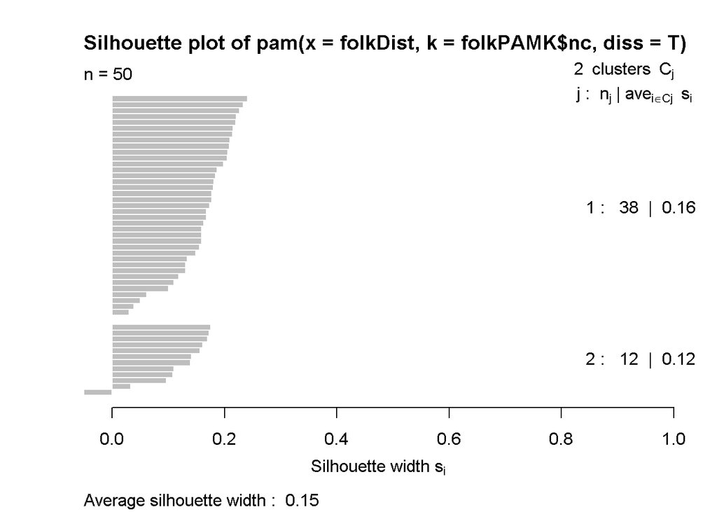

```r
plot(folkPAM)
```

With fewer observations, we would see labels next to each observation so we could see which is which. Here, we see one actually has a negative value, which means it does not fit well within its assigned cluster (but not badly enough to warrant its own cluster, or it would have returned 3 clusters).

In general, the fit is not good, because we see almost all the silhouette values are below 0.2–ideally, we’d want them all above 0.5. Some of this I’ve found is a result of the dichotomous data, I think because it just doesn’t carry enough information to create good correlations and cleanly-separated clusters. So keep that in mind when interpreting your results, if using dichotomous or ordinal data.

The `factoextra` functions don’t work with PAM objects, but we can use the `clusplot()` function in `cluster` to get a similar visualization.

```r
?clusplot
```

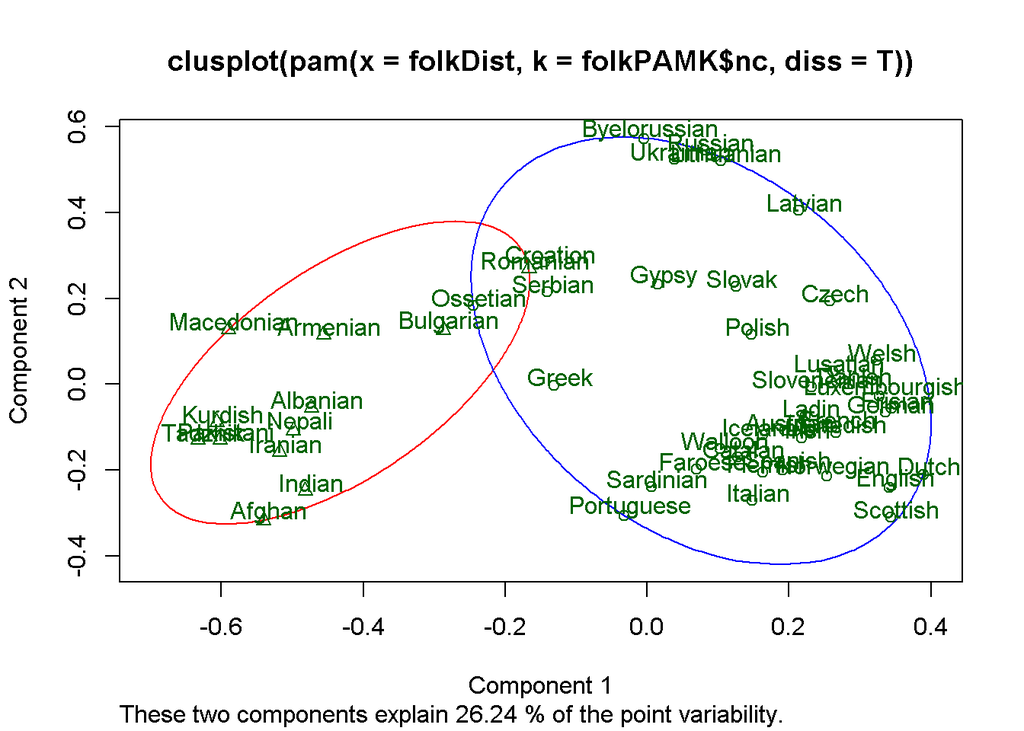

```r
clusplot(folkPAM, lines=0, color=T, labels=3)
```

Even though the fit isn’t great (and, as we can see, the first two components only explain 26% of the variance, which is also not good) the clusters it formed and the distances between societies make good intuitive sense.

### Exploratory factor analysis

Exploratory factor analysis (EFA) is another commonly used method, to look at underlying (“latent”) relationships between variables. It’s also a prerequisite to confirmatory factor analysis (CFA), a method in structural equation modeling that we’ll cover next time.

R `base` has a factor analysis function:

```r
?factanal
```

Here, for our Bob Marshall data again, we’ll use `fa()` in the `psych` package, since it has some extra useful options.

```r
?psych::fa
```

We also need the `GPArotation` package to rotate our result, which is a way of making factors easier to interpret by rotating their axes. Don’t worry about the math for now, just know that it’s a typical stage in factor analysis.

```r
install.packages("GPArotation")
```

The `psych` package has a couple methods to determine how many factors we should use. One of which uses the “Very Simple Structure” criterion (which you can read about on its help page) and the other is parallel analysis, which is a good, reliable method based on randomly permuting (mixing around) the data.

```r
?psych::vss
?psych::fa.parallel
```

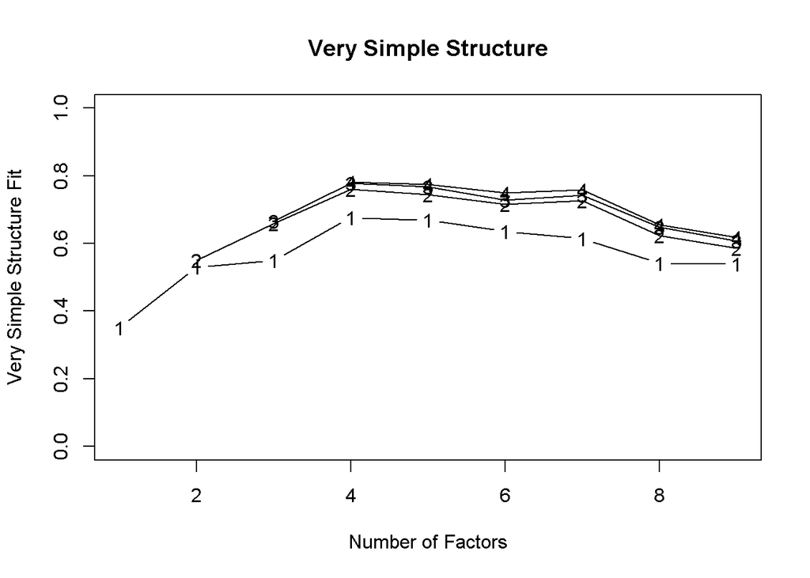

```
##
## Very Simple Structure
## Call: vss(x = bmLikCor, n = nrow(bmLikCor) - 1, rotate = "oblimin",
##     fm = "ml", n.obs = nrow(bmLik))
## VSS complexity 1 achieves a maximimum of 0.68  with  4  factors
## VSS complexity 2 achieves a maximimum of 0.76  with  4  factors
##
## The Velicer MAP achieves a minimum of 0.07  with  1  factors
## BIC achieves a minimum of  NA  with  5  factors
## Sample Size adjusted BIC achieves a minimum of  NA  with  5  factors
##
## Statistics by number of factors
##   vss1 vss2   map dof   chisq     prob sqresid  fit RMSEA    BIC SABIC
## 1 0.35 0.00 0.066  35 6.7e+02 5.6e-118     9.9 0.35  0.21 457.19   568
## 2 0.53 0.55 0.084  26 3.9e+02  7.6e-67     6.8 0.55  0.19 234.92   317
## 3 0.55 0.66 0.106  18 2.2e+02  4.9e-37     5.1 0.67  0.17 113.21   170
## 4 0.68 0.76 0.099  11 1.1e+02  1.2e-17     3.3 0.78  0.15  39.79    75
## 5 0.67 0.74 0.131   5 3.0e+01  1.7e-05     3.4 0.77  0.11  -0.39    15
## 6 0.64 0.72 0.198   0 1.4e+01       NA     3.8 0.75    NA     NA    NA
## 7 0.61 0.73 0.379  -4 1.1e-07       NA     3.4 0.77    NA     NA    NA
## 8 0.54 0.62 0.546  -7 2.3e-09       NA     5.1 0.66    NA     NA    NA
## 9 0.54 0.59 1.000  -9 0.0e+00       NA     5.7 0.62    NA     NA    NA
##   complex  eChisq    SRMR eCRMS  eBIC
## 1     1.0 9.9e+02 1.6e-01 0.186 781.0
## 2     1.1 5.4e+02 1.2e-01 0.159 380.5
## 3     1.3 2.7e+02 8.6e-02 0.136 162.6
## 4     1.3 7.0e+01 4.4e-02 0.088   4.2
## 5     1.4 1.7e+01 2.1e-02 0.064 -13.6
## 6     1.4 5.5e+00 1.2e-02    NA    NA
## 7     1.6 8.1e-08 1.5e-06    NA    NA
## 8     1.3 1.6e-09 2.1e-07    NA    NA
## 9     1.3 1.2e-17 1.8e-11    NA    NA
```

```r
vss(bmLikCor, n=nrow(bmLikCor)-1, rotate="oblimin", fm="ml", n.obs=nrow(bmLik))
```

VSS seems to give us 4 or 5 factors pretty consistently.

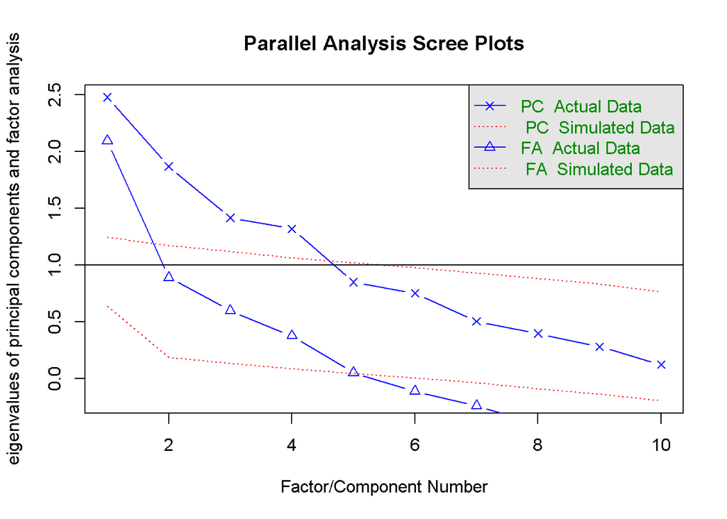

```
## Parallel analysis suggests that the number of factors =  5  and the number of components =  4
```

```r
fa.parallel(bmLikCor, fm="ml", n.obs=nrow(bmLik))
```

And parallel analysis says 5. Given the agreement, this seems like a good place to start. Notice that it gives us an estimate for the number of components, too, if we were running PCA.

Back to the point on rotation, we need to specify a method to use. The two options are an orthogonal rotation, which assumes that factors should not be correlated with one another at all, or an oblique rotation, which allows for correlations between factors. Unless we have a good basis for saying that the different factors we find should be completely distinct from one another, I tend toward oblique rotations. It usually doesn’t make much of a difference. The most common orthogonal rotation is `varimax` and a good oblique rotation is `oblimin`. You can always run both and compare, since EFA is exploratory by nature–just don’t do it to go “fishing” for better structure.

We also use a maximum likelihood estimator (`"ml"`) to fit our model. There are other options, which we’ll explore a little more in CFA.

```r
bmEFA = fa(bmLikCor, nfactors=5, rotate="oblimin", fm="ml", n.obs=nrow(bmLik))
bmEFA
```

```
## Factor Analysis using method =  ml
## Call: fa(r = bmLikCor, nfactors = 5, n.obs = nrow(bmLik), rotate = "oblimin",
##     fm = "ml")
## Standardized loadings (pattern matrix) based upon correlation matrix
##            ML1   ML2   ML3   ML4   ML5   h2    u2 com
## natural   0.85 -0.05  0.00  0.12 -0.03 0.74 0.264 1.1
## remotnes  0.98  0.04  0.03 -0.07  0.03 1.00 0.005 1.0
## scenic_b  0.05 -0.04  0.97 -0.01  0.02 1.00 0.005 1.0
## hunting  -0.03  0.99 -0.03  0.05  0.02 1.00 0.005 1.0
## fishing   0.11  0.67  0.02 -0.14 -0.06 0.45 0.546 1.2
## recent_f -0.13  0.17  0.39  0.23 -0.13 0.25 0.747 2.7
## test_ski  0.01  0.01 -0.01  0.94  0.03 0.90 0.105 1.0
## familiar  0.01  0.08  0.22  0.26 -0.45 0.32 0.683 2.2
## variety   0.06  0.01  0.03  0.14  0.70 0.56 0.444 1.1
## friend_s -0.12  0.05  0.28 -0.06  0.47 0.28 0.716 1.8
##
##                        ML1  ML2  ML3  ML4  ML5
## SS loadings           1.73 1.47 1.24 1.09 0.94
## Proportion Var        0.17 0.15 0.12 0.11 0.09
## Cumulative Var        0.17 0.32 0.44 0.55 0.65
## Proportion Explained  0.27 0.23 0.19 0.17 0.15
## Cumulative Proportion 0.27 0.49 0.69 0.85 1.00
##
##  With factor correlations of
##       ML1   ML2   ML3  ML4   ML5
## ML1  1.00 -0.02  0.47 0.05  0.10
## ML2 -0.02  1.00 -0.07 0.20 -0.10
## ML3  0.47 -0.07  1.00 0.21  0.11
## ML4  0.05  0.20  0.21 1.00  0.10
## ML5  0.10 -0.10  0.11 0.10  1.00
##
## Mean item complexity =  1.4
## Test of the hypothesis that 5 factors are sufficient.
##
## The degrees of freedom for the null model are  45  and the objective function was  3.23 with Chi Square of  1304.42
## The degrees of freedom for the model are 5  and the objective function was  0.07
##
## The root mean square of the residuals (RMSR) is  0.02
## The df corrected root mean square of the residuals is  0.06
##
## The harmonic number of observations is  409 with the empirical chi square  16.51  with prob <  0.0055
## The total number of observations was  409  with Likelihood Chi Square =  29.68  with prob <  1.7e-05
##
## Tucker Lewis Index of factoring reliability =  0.822
## RMSEA index =  0.111  and the 90 % confidence intervals are  0.074 0.15
## BIC =  -0.39
## Fit based upon off diagonal values = 0.99
## Measures of factor score adequacy
##                                                    ML1  ML2  ML3  ML4  ML5
## Correlation of (regression) scores with factors   1.00 1.00 1.00 0.95 0.80
## Multiple R square of scores with factors          0.99 0.99 0.99 0.90 0.64
## Minimum correlation of possible factor scores     0.99 0.99 0.99 0.80 0.29
```

```r
bmEFA$loadings
```

```
##
## Loadings:
##          ML1    ML2    ML3    ML4    ML5
## natural   0.847                0.123
## remotnes  0.981
## scenic_b                0.971
## hunting          0.985
## fishing   0.107  0.674        -0.143
## recent_f -0.134  0.175  0.388  0.231 -0.132
## test_ski                       0.941
## familiar                0.218  0.260 -0.447
## variety                        0.144  0.703
## friend_s -0.116         0.277         0.469
##
##                  ML1   ML2   ML3   ML4   ML5
## SS loadings    1.731 1.472 1.220 1.072 0.938
## Proportion Var 0.173 0.147 0.122 0.107 0.094
## Cumulative Var 0.173 0.320 0.442 0.549 0.643
```

(pdf / Rmd)